To read the file using `read.csv`

```r
act<-read.csv("activity.csv")
```

```r
act$hour<-as.integer(act$interval/100)
act$minute<-act$interval%%100
act$interval_new<-act$hour*60+act$minute
act$date_new<-as.POSIXlt(act$date)
```

To get the total number of steps per day we use the `aggregate` function and we assign that to the `spd` variable. To get the mean of steps per interval we use the `aggregate` function and we assign that to the `mpd` variable.

```r
spd<-aggregate(steps~date,data = act,sum,na.rm=TRUE)
mpd<-aggregate(steps~interval_new,data = act,mean,na.rm=TRUE)
```

To plot the histogram of the number of steps taken on each day.

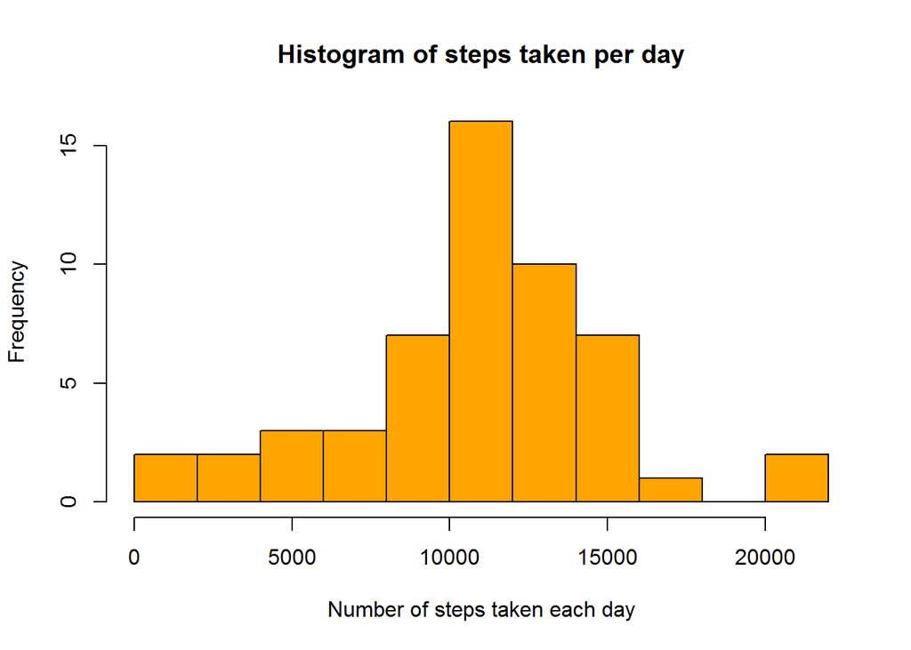

```r
hist(spd$steps,col = "orange",main = "Histogram of steps taken per day",xlab = "Number of steps taken each day",breaks = 10)
```

To take the mean and median of the no. of steps per day

```r
median_spd<-median(spd$steps)
mean_spd<-as.integer(mean(spd$steps))
median_spd
```

```
## [1] 10765
```

```r
mean_spd
```

```
## [1] 10766
```

[figure not shown]

```r
plot(steps~interval_new,data = act,type = "l",main = "5-minute interval and the average number of steps taken",xlab = "Interval",ylab = "Steps averaged across the days")
```

```r
which.max(mpd$steps)
```

```
## [1] 104
```

The total number of NA values in the data set is

```r
sum(is.na(act$steps))
```

```
## [1] 2304
```

The NA value for a particular instance would be assigned the mean value of the corresponding time interval.

For this we use a `for` loop, we check if the value is NA, whenever it is true we assigne the mean value of the time interval to that.

```r
act_new<-act
for(x in 1:nrow(act_new)){
     if(is.na(act_new$steps[x])){
         y<-which(mpd$interval_new==act_new$interval_new[x])
         act_new$steps[x]<-mpd$steps[y]
     }
}
```

The new data set created `act_new` consists of no NA values.